# Cau2

Đọc bộ dữ liệu train, test của MNIST từ Keras

```python
from tensorflow.keras.datasets import mnist

# Đọc dữ liệu
(train_images, train_labels), (test_images, test_labels) = mnist.load_data()
```

```
Downloading data from https://storage.googleapis.com/tensorflow/tf-keras-datasets/mnist.npz
11490434/11490434 ━━━━━━━━━━━━━━━━━━━━ 0s 0us/step
```

In ra kích thước của tập train, test

```python
# In kích thước
print("Train images shape:", train_images.shape)
print("Train labels shape:", train_labels.shape)
print("Test images shape:", test_images.shape)
print("Test labels shape:", test_labels.shape)
```

```
Train images shape: (60000, 28, 28)
Train labels shape: (60000,)
Test images shape: (10000, 28, 28)
Test labels shape: (10000,)
```

Chuẩn hóa các giá trị pixel của ảnh về đoạn [0,1]

```python
# Chuẩn hóa
train_images = train_images.astype('float32') / 255.0
test_images = test_images.astype('float32') / 255.0
```

Chia tập train ban đầu thành tập train và tập validaion theo tỷ lệ 8:2

```python
from sklearn.model_selection import train_test_split

# Chia tập train ban đầu thành train và validation
train_images, validation_images, train_labels, validation_labels = train_test_split(
    train_images, train_labels, test_size=0.2, random_state=42
)

# In kích thước
print("New train images shape:", train_images.shape)
print("New train labels shape:", train_labels.shape)
print("Validation images shape:", validation_images.shape)
print("Validation labels shape:", validation_labels.shape)
```

```
New train images shape: (48000, 28, 28)
New train labels shape: (48000,)
Validation images shape: (12000, 28, 28)
Validation labels shape: (12000,)
```

Xây dựng Neural Network gồm các layers

```python
from tensorflow.keras.models import Sequential
from tensorflow.keras.layers import Flatten, Dense, Dropout

# Xây dựng mô hình
model = Sequential([
    # Flatten layer: Chuyển từ 28x28 thành 784
    Flatten(input_shape=(28, 28)),

    # Dense layer: 128 neurons với hàm kích hoạt Relu
    Dense(128, activation='relu'),

    # Dropout layer: 20% các neurons bị tắt
    Dropout(0.2),

    # Dense layer: 10 neurons (số class), hàm kích hoạt Softmax
    Dense(10, activation='softmax')
])

# Hiển thị kiến trúc mô hình
model.summary()
```

```
Model: "sequential"
```

```
┏━━━━━━━━━━━━━━━━━━━━━━━━━━━━━━━━━━━━━━┳━━━━━━━━━━━━━━━━━━━━━━━━━━━━━┳━━━━━━━━━━━━━━━━━┓
┃ Layer (type)                         ┃ Output Shape                ┃         Param # ┃
┡━━━━━━━━━━━━━━━━━━━━━━━━━━━━━━━━━━━━━━╇━━━━━━━━━━━━━━━━━━━━━━━━━━━━━╇━━━━━━━━━━━━━━━━━┩
│ flatten (Flatten)                    │ (None, 784)                 │               0 │
├──────────────────────────────────────┼─────────────────────────────┼─────────────────┤
│ dense (Dense)                        │ (None, 128)                 │         100,480 │
├──────────────────────────────────────┼─────────────────────────────┼─────────────────┤
│ dropout (Dropout)                    │ (None, 128)                 │               0 │
├──────────────────────────────────────┼─────────────────────────────┼─────────────────┤
│ dense_1 (Dense)                      │ (None, 10)                  │           1,290 │
└──────────────────────────────────────┴─────────────────────────────┴─────────────────┘
```

```
 Total params: 101,770 (397.54 KB)
```

```
 Trainable params: 101,770 (397.54 KB)
```

```
 Non-trainable params: 0 (0.00 B)
```

Biên dịch mô hình

```python
model.compile(
    optimizer='adam',  # Sử dụng Adam optimizer
    loss='sparse_categorical_crossentropy',  # Hàm loss cho bài toán phân loại
    metrics=['accuracy']  # Đo lường bằng độ chính xác
)
```

Huấn luyện mô hình

```python
# Huấn luyện mô hình
history = model.fit(
    train_images, train_labels,
    validation_data=(validation_images, validation_labels),
    epochs=10,  # Số lần huấn luyện
    batch_size=32  # Số lượng mẫu mỗi batch
)

# Đánh giá trên tập test
test_loss, test_accuracy = model.evaluate(test_images, test_labels)
print("Test Loss:", test_loss)
print("Test Accuracy:", test_accuracy)
```

```
1500/1500 ━━━━━━━━━━━━━━━━━━━━ 8s 5ms/step - accuracy: 0.8465 - loss: 0.5281 - val_accuracy: 0.9536 - val_loss: 0.1609
1500/1500 ━━━━━━━━━━━━━━━━━━━━ 6s 4ms/step - accuracy: 0.9507 - loss: 0.1717 - val_accuracy: 0.9644 - val_loss: 0.1183
1500/1500 ━━━━━━━━━━━━━━━━━━━━ 10s 4ms/step - accuracy: 0.9638 - loss: 0.1206 - val_accuracy: 0.9709 - val_loss: 0.0957
1500/1500 ━━━━━━━━━━━━━━━━━━━━ 12s 5ms/step - accuracy: 0.9720 - loss: 0.0954 - val_accuracy: 0.9717 - val_loss: 0.0945
1500/1500 ━━━━━━━━━━━━━━━━━━━━ 5s 4ms/step - accuracy: 0.9756 - loss: 0.0812 - val_accuracy: 0.9749 - val_loss: 0.0840
1500/1500 ━━━━━━━━━━━━━━━━━━━━ 7s 5ms/step - accuracy: 0.9777 - loss: 0.0695 - val_accuracy: 0.9762 - val_loss: 0.0793
1500/1500 ━━━━━━━━━━━━━━━━━━━━ 10s 4ms/step - accuracy: 0.9812 - loss: 0.0600 - val_accuracy: 0.9787 - val_loss: 0.0781
1500/1500 ━━━━━━━━━━━━━━━━━━━━ 5s 4ms/step - accuracy: 0.9844 - loss: 0.0506 - val_accuracy: 0.9783 - val_loss: 0.0783
1500/1500 ━━━━━━━━━━━━━━━━━━━━ 12s 5ms/step - accuracy: 0.9853 - loss: 0.0483 - val_accuracy: 0.9768 - val_loss: 0.0791
1500/1500 ━━━━━━━━━━━━━━━━━━━━ 10s 4ms/step - accuracy: 0.9872 - loss: 0.0406 - val_accuracy: 0.9787 - val_loss: 0.0768
313/313 ━━━━━━━━━━━━━━━━━━━━ 1s 1ms/step - accuracy: 0.9741 - loss: 0.0913
Test Loss: 0.0776328295469284
Test Accuracy: 0.9778000116348267
```

Vẽ biểu đồ thể hiện accuracy, loss sau mỗi epoch.

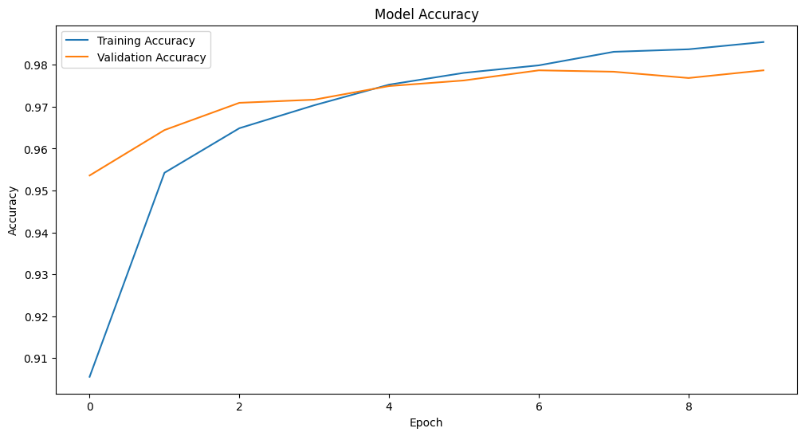

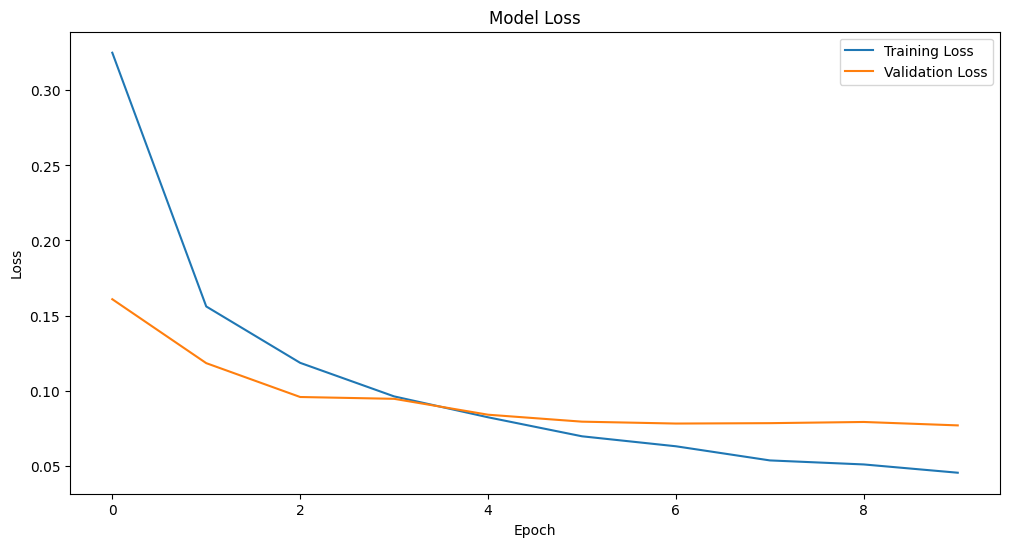

```python
import matplotlib.pyplot as plt

# Vẽ biểu đồ accuracy
plt.figure(figsize=(12, 6))
plt.plot(history.history['accuracy'], label='Training Accuracy')
plt.plot(history.history['val_accuracy'], label='Validation Accuracy')
plt.title('Model Accuracy')
plt.xlabel('Epoch')
plt.ylabel('Accuracy')
plt.legend()
plt.show()

# Vẽ biểu đồ loss
plt.figure(figsize=(12, 6))
plt.plot(history.history['loss'], label='Training Loss')
plt.plot(history.history['val_loss'], label='Validation Loss')
plt.title('Model Loss')
plt.xlabel('Epoch')
plt.ylabel('Loss')
plt.legend()
plt.show()
```

Dự đoán phân lớp cho tập test

```python
import numpy as np

# Dự đoán xác suất
predictions = model.predict(test_images)

# Chọn class có xác suất lớn nhất cho mỗi mẫu
predicted_classes = np.argmax(predictions, axis=1)
```

```
313/313 ━━━━━━━━━━━━━━━━━━━━ 1s 2ms/step
```

Tính và in ra Accuracy của mô hình trên tập test

```python
from sklearn.metrics import accuracy_score

# Tính độ chính xác
test_accuracy = accuracy_score(test_labels, predicted_classes)
print("Test Accuracy:", test_accuracy)
```

```
Test Accuracy: 0.9778
```

Tính và in ra Precision, Recall, F1-score của từng lớp và trung bình của mô hình trên tập test

```python
from sklearn.metrics import classification_report

# Tính Precision, Recall, F1-Score
report = classification_report(test_labels, predicted_classes, target_names=[str(i) for i in range(10)])
print("Classification Report:\n", report)
```

```
Classification Report:
               precision    recall  f1-score   support

           0       0.99      0.99      0.99       980
           1       0.99      0.99      0.99      1135
           2       0.98      0.97      0.97      1032
           3       0.97      0.98      0.97      1010
           4       0.96      0.99      0.97       982
           5       0.99      0.97      0.98       892
           6       0.98      0.98      0.98       958
           7       0.99      0.96      0.98      1028
           8       0.97      0.98      0.97       974
           9       0.97      0.97      0.97      1009

    accuracy                           0.98     10000
   macro avg       0.98      0.98      0.98     10000
weighted avg       0.98      0.98      0.98     10000
```

Hiển thị confusion matrix bằng heat map (bản đồ nhiệt)

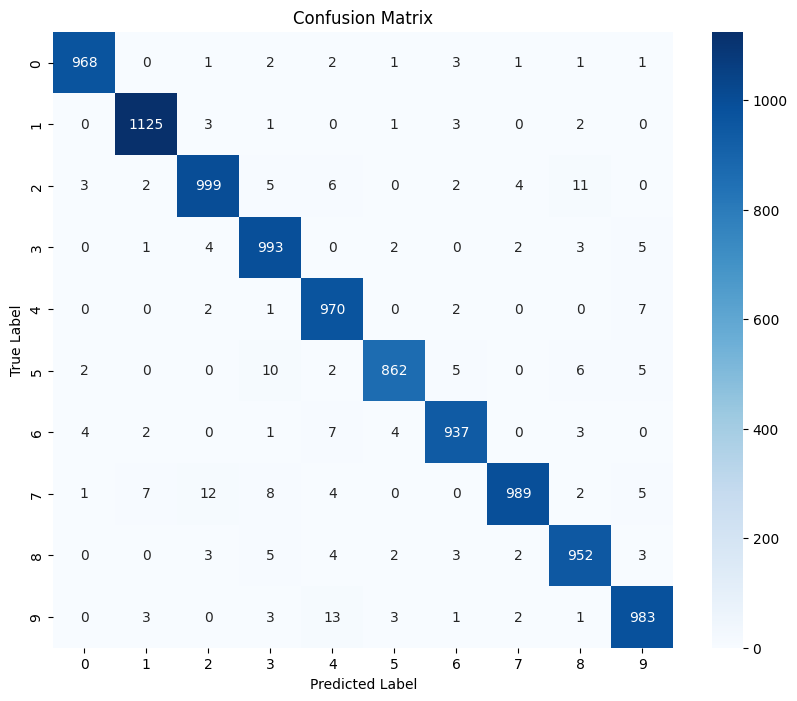

```python
from sklearn.metrics import confusion_matrix
import seaborn as sns

# Tính confusion matrix
conf_matrix = confusion_matrix(test_labels, predicted_classes)

# Vẽ heatmap
plt.figure(figsize=(10, 8))
sns.heatmap(conf_matrix, annot=True, fmt="d", cmap="Blues", xticklabels=[str(i) for i in range(10)],
            yticklabels=[str(i) for i in range(10)])
plt.title("Confusion Matrix")
plt.xlabel("Predicted Label")
plt.ylabel("True Label")
plt.show()
```

In ra kết quả phân lớp của 05 ảnh đầu tiên trong tập test

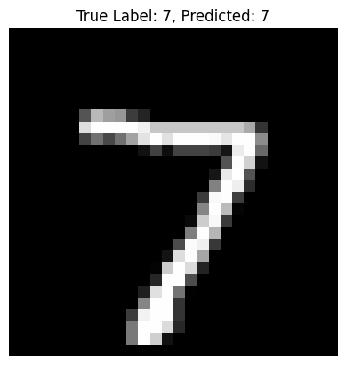

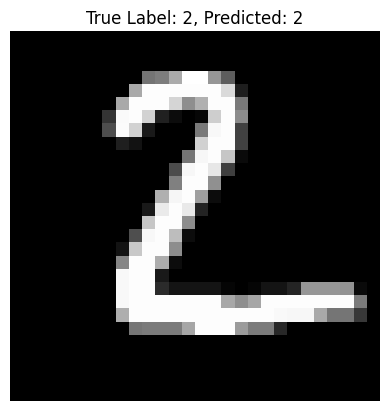

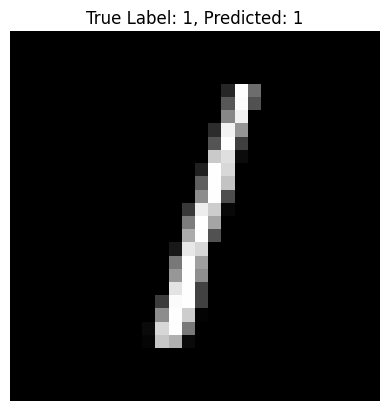

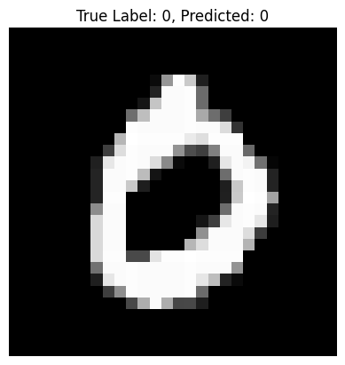

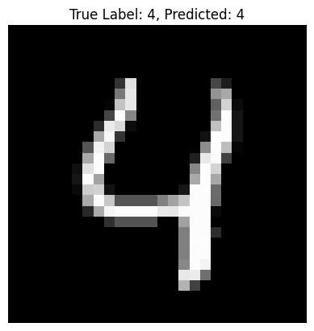

```python
# Hiển thị 5 ảnh đầu tiên
for image_index in range(5):
    plt.imshow(test_images[image_index], cmap='gray')
    plt.title(f"True Label: {test_labels[image_index]}, Predicted: {predicted_classes[image_index]}")
    plt.axis('off')
    plt.show()
```

In ra 05 kết quả đầu tiên phân lớp sai so với nhãn thực tế trong tập test

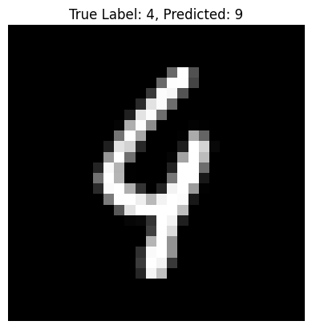

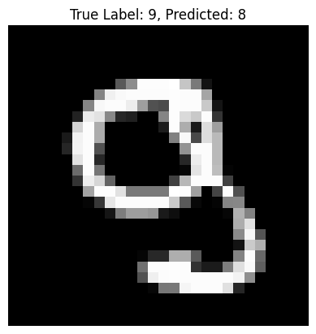

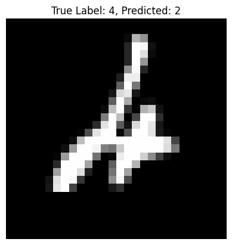

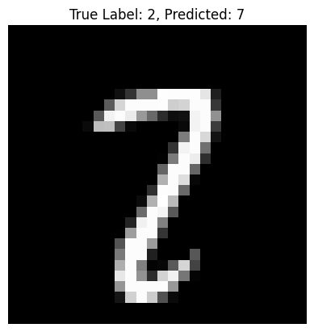

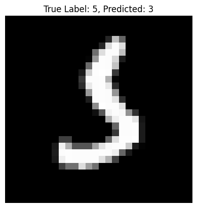

```python
# Tìm chỉ số các ảnh phân lớp sai
incorrect_indices = np.where(predicted_classes != test_labels)[0]

# Hiển thị 5 kết quả đầu tiên phân lớp sai
for i in range(5):
    index = incorrect_indices[i]
    plt.imshow(test_images[index], cmap='gray')
    plt.title(f"True Label: {test_labels[index]}, Predicted: {predicted_classes[index]}")
    plt.axis('off')
    plt.show()
```

```python
!pip install nbconvert
```

```python
from google.colab import drive
drive.mount('/content/drive')
```